# Case Study 1 - Predicting Life Expectancy

Modeling life expectancy is clearly in the realms of statistics but when you extend it to the Internet in an interactive and educational form, it becomes applied data science. In this walk-through, we’ll tie a simple linear regression model to a Flask web application, in essence, transforming an equation into an interactive tool from which the entire world can play with and learn from.

Let’s talk life expectancy. Though I see this topic as an important awareness tool, I apologize in advance to those that find it depressing. It’s up there with those interactive banking tools that remind you how much money you don’t have to properly retire.

This is a surprisingly easy model to build using solid data curated by top statisticians. Two top sources are the [World Health Organization (WHO)](http://www.who.int/gho/mortality_burden_disease/life_tables/en/) and the [Central Intelligence Agency (CIA)](https://www.cia.gov/library/publications/the-world-factbook/rankorder/2102rank.html). Here we’ll use the [World Health Organization (WHO) Global Health Observatory Data](http://www.who.int/gho/en/).

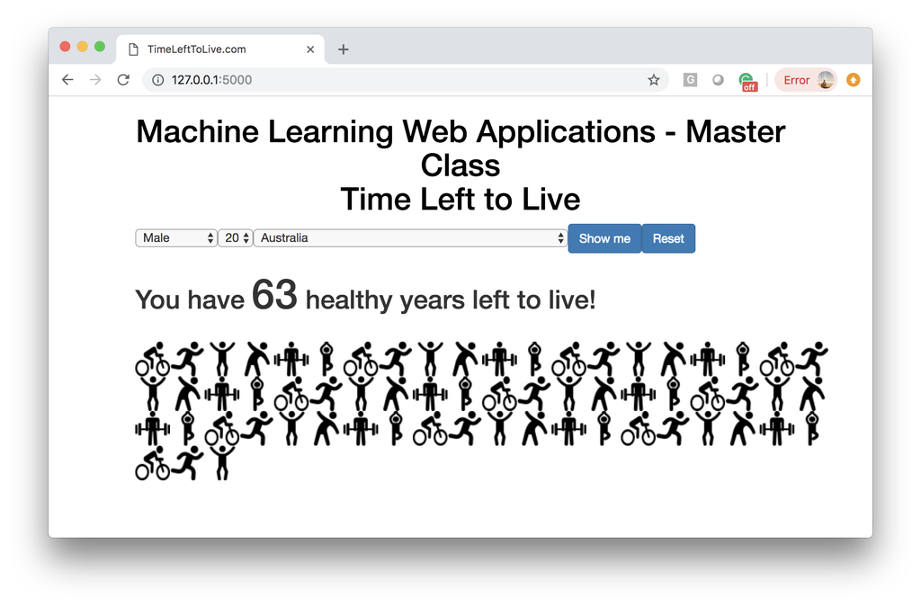

```python
from IPython.display import Image
Image(filename="Predicting-Life-Expectancy.png")
```

## Mortality Data

We’ll use the combined data sets of ‘Life expectancy at birth (years)’ and ‘Life expectancy at age 60 (years)’. This is going to give us two points for our linear regression from which we can easily extract any other age. Again, take this with a big grain of salt! These are only averages and life expectancy keeps improving everyday! From the WHO site:

**Life expectancy at birth (years)** The average number of years that a newborn could expect to live, if he or she were to pass through life exposed to the sex- and age-specific death rates prevailing at the time of his or her birth, for a specific year, in a given country, territory, or geographic area.

**Life expectancy at age 60 (years)** The average number of years that a person of 60 years old could expect to live, if he or she were to pass through life exposed to the sex- and age-specific death rates prevailing at the time of his or her 60 years, for a specific year, in a given country, territory, or geographic area.

## Simple Linear Regression and Predicting Life Expectancy

A linear regression model attempts to explain the relationship between two or more variables using a straight line. [ReliaSoft’s Experiment Design and Analysis Reference](http://reliawiki.org/index.php/Simple_Linear_Regression_Analysis).

We’re going to use the scipy.stats package for our linear regression. Let’s look at a simple example to illustrate how we can predict using a linear regression. We create a fictitious data set of two life expectancies, one for a newborn and another for a sixty-year-old:

```python
import pandas as pd
import matplotlib.pyplot as plt

# create fictitious data set
simple_life_dataset = pd.DataFrame({'Age':[0, 60], 'Life Expectancy':[90, 30]})
simple_life_dataset.head()
```

|  | Age | Life Expectancy |
| --- | --- | --- |
| 0 | 0 | 90 |
| 1 | 60 | 30 |

Now we feed the data into the stats.linregress function. We’ll only use two of its outputs, the slope and intercept. Those two values and the **y = mx+b** line equation, will give us everything we need to estimate life-expectancy for any age.

```python
import numpy as np
from scipy import stats
slope, intercept, r_value, p_value, std_err = stats.linregress(
    simple_life_dataset['Age'],
    simple_life_dataset['Life Expectancy'])
print('intercept: ', intercept)
print('slope: ', slope)
```

```
intercept:  90.0
slope:  -1.0
```

So, how many years left of life for a 20-year old according to our fictitious data? We apply the stats.linregress outputs to the y = mx+b line equation:

**Life Expectancy Estimate = Slope * Age + Intercept**

```python
np.ceil(slope * 20 + intercept)
```

```
70.0
```

We get 70 years of life left. And if we plot our fictitious data set along with our new estimate:

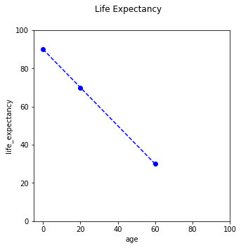

```python
fig, axes = plt.subplots(figsize=(5,5))
x = [0,20,60]
y = [90, 70, 30]
axes.plot(x,y, color='blue', linestyle='--', marker='o')
fig.suptitle('Life Expectancy')
axes.set_xlabel('age')
axes.set_xlim([-5,100])
axes.set_ylabel('life_expectancy')
axes.set_ylim([0,100])
plt.show()
```

## WHO Mortality Data

Let’s download real data and save it locally. Then let’s run through the exact same exercise as above:

```python
# load WHO longevity data
# http://apps.who.int/gho/data/node.main.688
who_list = pd.read_csv('http://apps.who.int/gho/athena/data/GHO/WHOSIS_000001,WHOSIS_000015?filter=COUNTRY:*&x-sideaxis=COUNTRY;YEAR&x-topaxis=GHO;SEX&profile=verbose&format=csv')
# save a local copy of the data set for our Flask prototype later on
who_list.to_csv('WHOSIS_000001,WHOSIS_000015.csv')

# Keep only useful features fix case display of country text
who_list = who_list[['GHO (DISPLAY)', 'YEAR (CODE)' , 'COUNTRY (DISPLAY)', 'SEX (DISPLAY)', 'Numeric']]
who_list['COUNTRY (DISPLAY)'] = [ctry.title() for ctry in who_list['COUNTRY (DISPLAY)'].values]
# print a few rows
who_list[who_list['COUNTRY (DISPLAY)']=='France'].head(10)
```

|  | GHO (DISPLAY) | YEAR (CODE) | COUNTRY (DISPLAY) | SEX (DISPLAY) | Numeric |
| --- | --- | --- | --- | --- | --- |
| 209 | Life expectancy at birth (years) | 2011 | France | Female | 84.82901 |
| 827 | Life expectancy at birth (years) | 2015 | France | Male | 79.82015 |
| 1030 | Life expectancy at age 60 (years) | 2016 | France | Female | 27.88425 |
| 1136 | Life expectancy at age 60 (years) | 2000 | France | Male | 20.55465 |
| 1383 | Life expectancy at birth (years) | 2016 | France | Both sexes | 82.94602 |
| 1412 | Life expectancy at birth (years) | 2001 | France | Male | 75.74738 |
| 1656 | Life expectancy at birth (years) | 2002 | France | Both sexes | 79.51011 |
| 1753 | Life expectancy at age 60 (years) | 2007 | France | Both sexes | 24.62560 |
| 1894 | Life expectancy at age 60 (years) | 2002 | France | Female | 25.77937 |
| 2277 | Life expectancy at birth (years) | 2009 | France | Male | 78.04598 |

```python
country = 'United States Of America'
sex = 'Male'
# pull latest entries for birth and 60 years for a country and gender
sub_set = who_list[who_list['COUNTRY (DISPLAY)'].str.startswith(country, na=False)]
sub_set = sub_set[sub_set['SEX (DISPLAY)'] == sex]
# sort by year in descending order to work with the latest read
sub_set = sub_set.sort_values('YEAR (CODE)', ascending=False)
sub_set_birth = sub_set[sub_set['GHO (DISPLAY)'] == 'Life expectancy at birth (years)']
sub_set_60 = sub_set[sub_set['GHO (DISPLAY)'] == 'Life expectancy at age 60 (years)']
print('sub_set_birth:')
print(sub_set_birth.head(5))
print('sub_set_60:')
print(sub_set_60.head(5))
```

```
sub_set_birth:
                          GHO (DISPLAY)  YEAR (CODE)  \
18507  Life expectancy at birth (years)         2016
3496   Life expectancy at birth (years)         2015
2393   Life expectancy at birth (years)         2014
15541  Life expectancy at birth (years)         2013
7899   Life expectancy at birth (years)         2012

              COUNTRY (DISPLAY) SEX (DISPLAY)   Numeric
18507  United States Of America          Male  76.01672
3496   United States Of America          Male  76.22922
2393   United States Of America          Male  76.63770
15541  United States Of America          Male  76.61551
7899   United States Of America          Male  76.62045
sub_set_60:
                           GHO (DISPLAY)  YEAR (CODE)  \
2941   Life expectancy at age 60 (years)         2016
12184  Life expectancy at age 60 (years)         2015
6026   Life expectancy at age 60 (years)         2014
1055   Life expectancy at age 60 (years)         2013
18079  Life expectancy at age 60 (years)         2012

              COUNTRY (DISPLAY) SEX (DISPLAY)   Numeric
2941   United States Of America          Male  21.75191
12184  United States Of America          Male  21.75415
6026   United States Of America          Male  21.91776
1055   United States Of America          Male  21.86298
18079  United States Of America          Male  21.87331
```

Let’s pull the two latest data points from the WHO data set and plot it out:

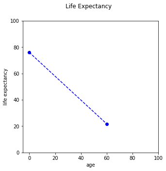

```python
# create data set with both points as shown in first example
lf_at_birth = sub_set_birth['Numeric'].values[0]
lf_at_60 = sub_set_60['Numeric'].values[0]
# let's organize our data and plot
age = [0,60]
life_expectancy = [lf_at_birth, lf_at_60]
fig, axes = plt.subplots(figsize=(5,5))
x = age
y = life_expectancy
axes.plot(x,y, color='blue', linestyle='--', marker='o')
fig.suptitle('Life Expectancy')
axes.set_xlabel('age')
axes.set_xlim([-5,100])
axes.set_ylabel('life expectancy')
axes.set_ylim([0,100])
plt.show()
```

And now, let’s estimate my life expectancy:

```python
# model
slope, intercept, r_value, p_value, std_err = stats.linregress(age, life_expectancy)
print('intercept: ', intercept)
print('slope: ', slope)

# predict life expectancy for an 50-year-old male in the USA:
np.ceil(slope * 50 + intercept)
```

```
intercept:  76.01671999999999
slope:  -0.9044134999999998
```

```
31.0
```

Thirty-one more years, better make them count! Now, let’s wrap all the above code into a function so we can easily predict other ages with other parameters (and this will make our lives much easier when we port this out to Flask).

```python
def get_life_expectancy(age, country, sex):
    # pull latest entries for birth and 60 years
    sub_set = who_list[who_list['COUNTRY (DISPLAY)'].str.startswith(country, na=False)]
    sub_set = sub_set[sub_set['SEX (DISPLAY)'] == sex]
    sub_set = sub_set.sort_values('YEAR (CODE)', ascending=False)
    sub_set_birth = sub_set[sub_set['GHO (DISPLAY)'] == 'Life expectancy at birth (years)']
    sub_set_60 = sub_set[sub_set['GHO (DISPLAY)'] == 'Life expectancy at age 60 (years)']

    # not all combinations exsits so check that we have data for both
    if len(sub_set_birth['Numeric']) > 0 and len(sub_set_60['Numeric']) > 0:
        # create data set with both points as shown in first example
        lf_at_birth = sub_set_birth['Numeric'].values[0]
        lf_at_60 = sub_set_60['Numeric'].values[0]

        # model
        slope, intercept, r_value, p_value, std_err = stats.linregress([0,60],[lf_at_birth, lf_at_60])

        # predict for the age variable
        return(np.ceil(slope * age + intercept))
    else:
        return None
```

And let’s run a quick test:

```python
# test the function out using a 22-year-old Japanese female:
get_life_expectancy(22, 'Japan', 'Female')
```

```
66.0
```

## Prototyping Our Model Using Flask

### pip3 install Flask

If you are having issues with Flask, go through the official documention at http://flask.pocoo.org/

```python
from IPython.display import Image
Image(filename="static/images/Cycling.png")
```

[output not shown]

```python
Image(filename="static/images/Yoga.png")
```

[output not shown]

```python
Image(filename="static/images/WeightLifting.png")
```

[output not shown]

```python
Image(filename="static/images/Stretching.png")
```

[output not shown]

```python
Image(filename="static/images/JumpingJack.png")
```

[output not shown]

```python
Image(filename="static/images/Jogging.png")
```

[output not shown]

[output not shown]

### main.py

Create a Python file in your favorite text editor or Python IDE and name in "main.py" and copy/paste the below code into it:

```
from flask import Flask, render_template, request, url_for, Markup
import pandas as pd
import numpy as np
from scipy import stats
import logging
import datetime
import os.path

app = Flask(__name__)

app.config["DEBUG"] = True
# constructor - load once (otherwise setup a local csv copy to save on bandwidth usage)
BASE_DIR = os.path.dirname(os.path.abspath(__file__))
app.logger.info(BASE_DIR)

src = os.path.join(BASE_DIR, 'WHOSIS_000001,WHOSIS_000015.csv')
who_list = pd.read_csv(src)
who_list = who_list[['GHO (DISPLAY)', 'YEAR (CODE)' , 'COUNTRY (DISPLAY)', 'SEX (DISPLAY)', 'Numeric']]
who_list['COUNTRY (DISPLAY)'] = [ctry.title() for ctry in who_list['COUNTRY (DISPLAY)'].values]
country_list = sorted(set(who_list['COUNTRY (DISPLAY)'].values))
def get_life_expectancy(age, country, sex):
    # pull latest entries for birth and 60 years
    sub_set = who_list[who_list['COUNTRY (DISPLAY)'].str.startswith(country, na=False)]
    sub_set = sub_set[sub_set['SEX (DISPLAY)'] == sex]
    sub_set = sub_set.sort_values('YEAR (CODE)', ascending=False)
    sub_set_birth = sub_set[sub_set['GHO (DISPLAY)'] == 'Life expectancy at birth (years)']
    sub_set_60 = sub_set[sub_set['GHO (DISPLAY)'] == 'Life expectancy at age 60 (years)']
    # not all combinations exsits so check that we have data for both
    if len(sub_set_birth['Numeric']) > 0 and len(sub_set_birth['Numeric']) > 0:
        # create data set with both points as shown in first example
        lf_at_birth = sub_set_birth['Numeric'].values[0]
        lf_at_60 = sub_set_60['Numeric'].values[0]
        # model
        slope, intercept, r_value, p_value, std_err = stats.linregress([0,60],[lf_at_birth, lf_at_60])
        # predict for the age variable
        return(np.ceil(slope * age + intercept))
    else:
        return None

@app.route('/', methods=['POST', 'GET'])
def interact_life_expectancy():
    # select box defaults
    default_age = 'Select Age'
    selected_age = default_age
    default_sex = 'Select Gender'
    selected_sex = default_sex
    default_country = 'Select Country'
    selected_country = default_country

    # data carriers
    string_to_print = ''
    healthy_image_list = []
    if request.method == 'POST':
        # clean up age field
        selected_age = request.form["age"]
        if (selected_age == default_age):
            selected_age = int(29)
        else:
            selected_age = selected_age
        # clean up sex field
        selected_sex = request.form["sex"]
        if (selected_sex == default_sex):
            selected_sex = 'Both sexes'
        # clean up country field
        selected_country = request.form["country"]
        if (selected_country == default_country):
            selected_country = 'United States Of America'

        # estimate lifespan
        current_time_left = get_life_expectancy(age=int(selected_age), country=selected_country, sex=selected_sex)

        if (current_time_left is not None):
            # create output string
            string_to_print = Markup("You have <font size='+10'>" + str(int(np.ceil(current_time_left))) + "</font> healthy years left to live!")
        else:
            string_to_print = Markup("Error! No data found for selected parameters")
            current_time_left = 1
        # healthy years
        healthy_image_list = []
        # squat.png, stretch.png, jog.png
        healthy_years_left = int(np.ceil(current_time_left))
        image_switch=0
        if (healthy_years_left > 0):
            for y in range(healthy_years_left):
                if image_switch == 0:
                    healthy_image_list.append('static/images/Cycling.png')
                elif image_switch == 1:
                    healthy_image_list.append('static/images/Jogging.png')
                elif image_switch == 2:
                    healthy_image_list.append('static/images/JumpingJack.png')
                elif image_switch == 3:
                    healthy_image_list.append('static/images/Stretching.png')
                elif image_switch == 4:
                    healthy_image_list.append('static/images/WeightLifting.png')
                else:
                    healthy_image_list.append('static/images/Yoga.png')
                    image_switch = -1
                image_switch += 1

    return render_template('life.html',
                            country_list = country_list,
                            default_country = selected_country,
                            default_age=selected_age,
                            default_sex=selected_sex,
                            string_to_print = string_to_print,
                            healthy_image_list = healthy_image_list)


# when running app locally
if __name__=='__main__':
    app.run(debug=True)
```

### life.html

Still in your favorite text editor or IDE create an HTML file called "life.html" and copy/paste the below code into it:

```
<!DOCTYPE html>
<HTML lang="en">
<HEAD>
  <TITLE>Time Left To Live</TITLE>
  <META charset="utf-8">
  <META name="viewport" content="width=device-width, initial-scale=1">
  <link rel="stylesheet" href="https://maxcdn.bootstrapcdn.com/bootstrap/3.3.7/css/bootstrap.min.css">
  <script src="https://ajax.googleapis.com/ajax/libs/jquery/3.2.1/jquery.min.js"></script>
  <script src="https://maxcdn.bootstrapcdn.com/bootstrap/3.3.7/js/bootstrap.min.js"></script>
</HEAD>
<BODY>
<DIV class="container">
  <DIV class="row">

    <table>
            <tr>
        <td width="900px" style="text-align:center;">
        <h1><font color="black">Machine Learning Web Applications - Master Class<BR>
        Time Left to Live</font></h1>
    </td>
    </tr> <table>

    <FORM id='submit_params' method="POST" action="{{url_for('interact_life_expectancy')}}">
      <SELECT class="selectpicker" name="sex">
          <option value="{{default_sex}}" selected>{{default_sex}}</option>
          <option>Both sexes</option>
          <option>Female</option>
          <option>Male</option>
      </SELECT>
      <SELECT class="selectpicker" name="age">
          <option value="{{default_age}}" selected>{{default_age}}</option>
           {% for age in range(1,100) %}
               <option value="{{age}}">{{age}}</option>
           {% endfor %}
        </SELECT>

       <SELECT class="selectpicker"  name="country">
            <option value="{{default_country}}" selected>{{default_country}}</option>
            {% for country in country_list %}
              <option value="{{country}}">{{country}}</option>
            {% endfor %}
          </SELECT>

       <button type="submit" class="btn btn-primary">Show me</button>
       <button type="button" class="btn btn-primary" onclick="location.href='/';" value="Reset">Reset</button>
    </FORM>
<BR>
<H2>{{string_to_print}}</H2>
<BR>
<TABLE>
<TR>
{% for imag in healthy_image_list %}
  {% if loop.index == 21 or loop.index == 41 or loop.index == 61 or loop.index == 81 %}
    </TR><TR>
  {% endif %}
  <td><img src={{imag}} width="40" height="40"></td>

{% endfor %}

</TR>
</TABLE>
</BODY>
</HTML>
```